# Amsterdam city swim

The open water swimming event through the canals of Amsterdam.

## Housing during the event

### Tourist tax

1. What Amsterdam will receive from tourist tax if the event lasts a week and you will have 30.000 visitors?

```python
import pandas as pd
import os
import matplotlib.pyplot as plt
import networkx as nx

df = pd.read_csv('C:/Users/pelle/Downloads/listings.csv')

# We assume that all the airbnb adresses are available for one week and assume that people stay 7 days. We filter the airbnb adresses where the number of minimum nights is bigger than 7.
filtered_df = df[df['minimum_nights'] <= 7]
```

```python
price_per_night = filtered_df['price'].mean()
print(f'The average price per night is \N{euro sign}{price_per_night}')
```

```
The average price per night is €256.77000622277535
```

The tourists will stay seven nights. Tourist tax for short-stay accomodation is 10% in Amsterdam (source: https://www.amsterdam.nl/en/municipal-taxes/tourist-tax-(toeristenbelasting)/)

```python
tax_for_the_week = price_per_night * 7 * 0.10 * 30000
print(f'The estimated tourist tax for the week will be \N{euro sign}{tax_for_the_week}')
```

```
The estimated tourist tax for the week will be €5392170.130678282
```

### AirBnB

2. Plot the amount of AirBnB locations per neighbourhood.

```python
airbnb_per_neigh = df.groupby('neighbourhood')['id'].nunique()
print(airbnb_per_neigh)
```

```
neighbourhood
Bijlmer-Centrum                             47
Bijlmer-Oost                                39
Bos en Lommer                              424
Buitenveldert - Zuidas                     100
Centrum-Oost                               793
Centrum-West                              1006
De Aker - Nieuw Sloten                      74
De Baarsjes - Oud-West                    1382
De Pijp - Rivierenbuurt                    935
Gaasperdam - Driemond                       51
Geuzenveld - Slotermeer                    116
IJburg - Zeeburgereiland                   183
Noord-Oost                                 137
Noord-West                                 218
Oostelijk Havengebied - Indische Buurt     320
Osdorp                                      44
Oud-Noord                                  402
Oud-Oost                                   506
Slotervaart                                164
Watergraafsmeer                            262
Westerpark                                 584
Zuid                                       599
Name: id, dtype: int64
```

```python
airbnb_per_neigh_sorted = airbnb_per_neigh.sort_values(ascending=False)
```

[output not shown]

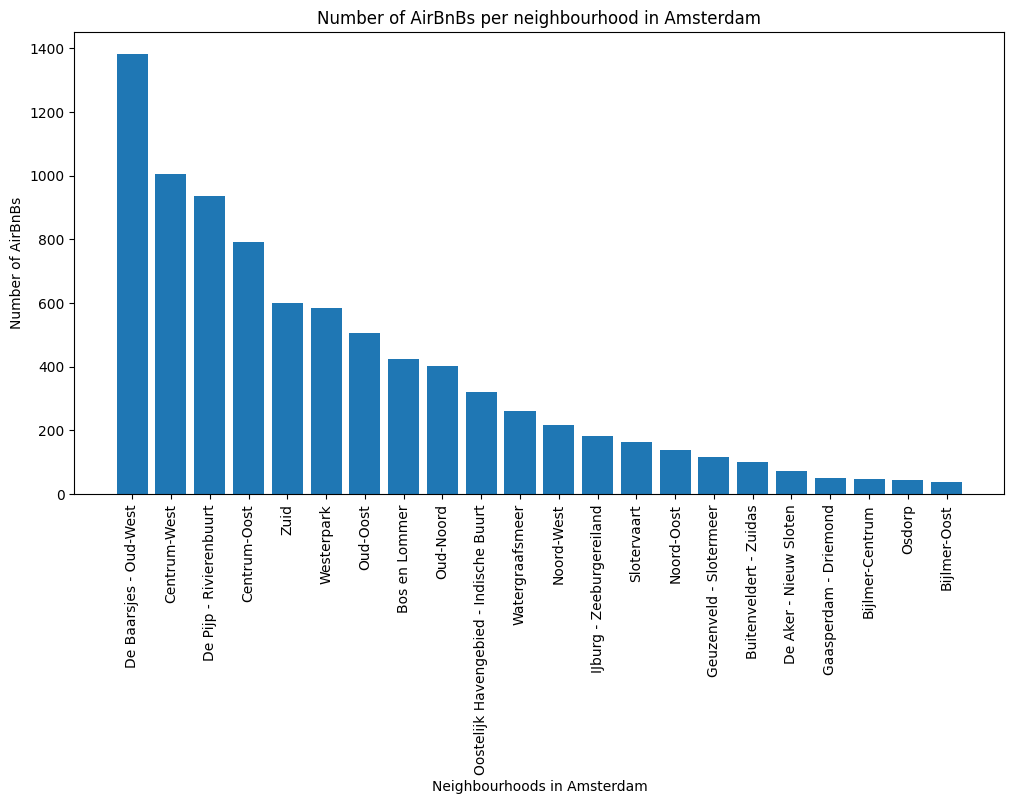

```python
plt.figure(figsize=(12, 6))
plt.bar(airbnb_per_neigh_sorted.index, airbnb_per_neigh_sorted.values)
plt.xlabel('Neighbourhoods in Amsterdam')
plt.ylabel('Number of AirBnBs')
plt.xticks(rotation=90)
plt.title('Number of AirBnBs per neighbourhood in Amsterdam')
plt.show()
```

3. Which street in Amsterdam has the most AirBnB apartments?

```python
import googlemaps

API_KEY = 'Private'

gmaps = googlemaps.Client(key=API_KEY)

# Iterate through each row in the dataset
for index, row in df.iterrows():
    latitude = row['latitude']
    longitude = row['longitude']

    reverse_geocode_result = gmaps.reverse_geocode((latitude, longitude))

    if reverse_geocode_result:
        formatted_address = reverse_geocode_result[0]['formatted_address']

        # Store the address in a new column
        df.at[index, 'address'] = formatted_address
```

Now we have all AirBnB adresses in a new colom.

```python
print(df['address'])
```

```
0       Jisperveldstraat 630, 1024 BD Amsterdam, Nethe...
1         Houtmankade 157, 1013 MV Amsterdam, Netherlands
2       Centrale Markthallen 26, 1051 KL Amsterdam, Ne...
3          IJsbaanpad 66E, 1076 CW Amsterdam, Netherlands
4       Egelantiersgracht 46B, 1015 RM Amsterdam, Neth...
                              ...
8381    Johan van Hasseltkade 304, 1032 LP Amsterdam, ...
8382    Meidoornplein 37HS, 1031 GB Amsterdam, Netherl...
8383         Molenwerf 16, 1014 BG Amsterdam, Netherlands
8384         Pijlsteeg 23, 1012 HH Amsterdam, Netherlands
8385    Boterdiepstraat 34I, 1079 SX Amsterdam, Nether...
Name: address, Length: 8386, dtype: object
```

```python
# Only the streetnames are relevant
df['street_name'] = df['address'].str.replace(r'\s\d.*', '', regex=True)
street_counts = df['street_name'].value_counts()
print(street_counts)
```

```
street_name
Prinsengracht                            98
Hoofdweg                                 70
Keizersgracht                            67
Admiraal de Ruijterweg                   58
Nassaukade                               57
                                         ..
Amsterdam, Burgemeester de Vlugtlaan,     1
Nicolaas Beetsplantsoen                   1
Fritz Dietrich Kahlenbergstraat           1
Amsterdam, Majanggracht,                  1
Kazernestraat                             1
Name: count, Length: 2223, dtype: int64
```

The street with the most AirBnb locations is Prinsengracht.

4. Try to cross reference the data from the AirBnB dataset with the BBGA. Can you figure out if all apartments of AirBnB are designated as housing? Which number of apartments are not rented out all the time but are also used as normal housing?

We have looked in the documents 'Het BBGA in csv formaat' and 'BBGA Metadata indicatoren definities'. We found out in the Metadata file that there is information available about Airbnb in Amsterdam. However we were not able to find this information in the 'Het BBGA in csv formaat' file. Because we were curiouse we looked further for a database of Amsterdam. We came on this site: https://api.data.amsterdam.nl/v1/bbga/. However we are not able at this moment to retrieve data from here. However, from the listings document we can see the availability of the AirBnBs.

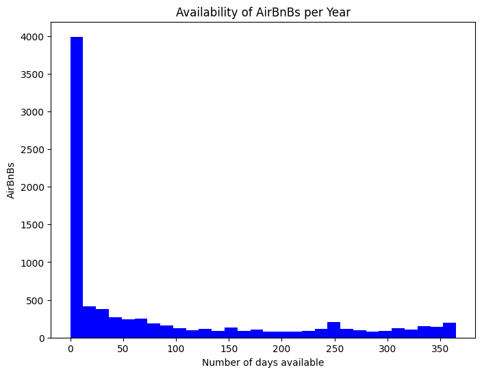

```python
availability_365_data = df['availability_365']

# Plotting
plt.figure(figsize=(8, 6))
plt.hist(availability_365_data, bins=30, color='blue')
plt.xlabel('Number of days available')
plt.ylabel('AirBnBs')
plt.title('Availability of AirBnBs per Year')
plt.show()
```

We see that most AirBnBs are not long available per year and are probably used in different ways like housing the other days.

### Hotel rooms

5. How many hotel rooms should be built if Amsterdam wants to accommodate the same number of tourists?

```python
#Assumptions: 30,000 tourists.
#The event will be hosted in May.
#Each tourist gets their own room.

hotelrooms = pd.read_csv("C:/Users/pelle/Downloads/cbshotels.csv")

Hotelrooms_ams_may = hotelrooms.loc[(hotelrooms["Star rating"] == "Total") &
                     (hotelrooms["Regions"] == "Amsterdam") &
                     (hotelrooms["Periods"] == "2023 May*")]

print(Hotelrooms_ams_may)



#The data set we found from CBS includes youth hostels and bed-and-breakfasts within its definition of hotel,
#so it overcalculates the number of available rooms for this purpose.
#If the data set simply had hotel numbers, we would use the following code to calculate the number of rooms needed.

open_rooms = 41695
total_tourists = 30000

print("The number of hotel rooms needed in Amsterdam is", total_tourists - open_rooms)
```

```
   Star rating    Regions    Periods Total accommodations Room (number)  \
21       Total  Amsterdam  2023 May*                             41,840

   Open accommodations Room (number)
21                            41,695
The number of hotel rooms needed in Amsterdam is -11695
```

We see that the number of hotelrooms in Amsterdam in May 2023 is 41840. However only 41695 were available in that month so this is the number we calculate with. We conclude that there would be no need to build more hotel rooms.

### Licenses AirBnB

6. How many different licenses are issued?

```python
amount_licences = df['license'].nunique()
print("Number of different types of licenses:", amount_licences)
```

```
Number of different types of licenses: 7288
```